# OZNAL Zadanie 1

Roman Bitarovsky a Roman Osadsky

04.04.2024

# Predstavenie datasetu

Náš dataset obsahuje informácie o ovzduší a meracích staniciach ktoré dané merania vykonávali. Je zložený z dvoch súborov a to: - measurements.csv - stations.csv ## Skratky: - PM2.5 - Particulate Matter (µg/m3)  
- PM10 - Particulate Matter (µg/m3)  
- NOx - Nitrogen Oxides (µg/m3)  
- NO2 - Nitrogen Dioxide (µg/m3)  
- SO2 - Sulfur Dioxide (µg/m3)  
- CO - Carbon Monoxide emissions (µg/m3)  
- CO2 - Carbon Dioxide (µg/m3)  
- PAHs - Polycyclic Aromatic Hydrocarbons (µg/m3)  
- NH3 - Ammonia trace (µg/m3)  
- Pb - Lead (µg/m3)  
- TEMP - Temperature (degree Celsius)  
- DEWP - Dew point temperature (degree Celsius)  
- PRES - Pressure (hPa, <100, 1050>)  
- RAIN - Rain (mm)  
- WSPM - Wind Speed (m/s)  
- WD - Wind Direction  
- VOC - Volatile Organic Compounds  
- CFCs - Chlorofluorocarbons  
- C2H3NO5 - Peroxyacetyl nitrate  
- H2CO - Plywood emit formaldehyde  
- GSTM1 - Glutathione-S transferase M1  
- 1-OHP - 1-hydroxypyrene  
- 2-OHF - 2-hydroxyfluorene  
- 2-OHNa - 2-hydroxynaphthalene  
- N2 - Nitrogen  
- O2 - Oxygen  
- O3 - Ozone  
- Ar - Argon  
- Ne - Neon  
- CH4 - Methane  
- He - Helium  
- Kr - Krypton  
- I2 - Iodine  
- H2 - Hydrogen  
- Xe - Xenon

# Initializácia a načítanie dát

```r
getwd()
```

```
## [1] "/Users/roman/Desktop/development/oznal_project1/part1"
```

```r
#setwd('/Users/roman.osadsky/Desktop/ROMAN/FIIT/OZNAL_PROJECT/oznal_project1')
setwd('/Users/roman/Desktop/development/oznal_project1/')
#setwd(getwd())
```

Importovanie knižníc

```r
library(dplyr)
```

```r
library(ggplot2)
library(GGally)
library(tidyverse)
library(caret)
library(tidyr)
library(e1071)
library(corrplot)
library(MASS)
library(reshape2)
library(gridExtra)
library(pROC)
```

Načítanie dát

```r
labor_measurements <- read.csv('/Users/roman/Desktop/development/oznal_project1/data/measurements.csv', sep = '\t')
labor_stations <- read.csv('/Users/roman/Desktop/development/oznal_project1/data/stations.csv', sep = '\t')
```

# Základné preskúmanie dát

Zobrazenie prvých riadkov datasetov, ich rozmerov a typov atribútov

## Merenia

```r
head(labor_measurements)
```

```
##   latitude    PM2.5     NOx     PM10 C2H3NO5     CH4  longitude       Pb
## 1 37.71715  8.47714 9.21522  9.38738 1.51791 7.84989 -122.40433 59.51096
## 2 -1.26753  8.95287 8.04229  8.78120 0.86506 7.48764  116.82887 57.03798
## 3 25.87498 11.41105 7.80172  6.67488 0.20478 8.32353   86.59611 78.98660
## 4 53.02330  5.41284 9.53800  7.01510 0.13092 6.36073   -1.48119 60.70261
## 5 -7.09810  5.59043 6.87675  6.19817 0.19487 6.55752  109.32430 79.16126
## 6 -0.35817  6.91056 6.76613 10.57920 4.65631 6.57000   42.54536 54.80587
##       TEMP      NH3     SO2       O3      CO    PAHs     H2CO     PRES warning
## 1 20.05101 10.43604 5.81201  7.77502 9.69678 8.62090 47.64810 1139.127       0
## 2 20.34841  9.19522 8.62588 11.61089 4.92266 6.96953 42.66369 1144.575       1
## 3 19.57588  5.00666 6.37696 11.20430 7.61260 7.88382 48.15920 1131.932       1
## 4 20.51904  8.38101 9.96460  6.31462 6.68230 9.13018 30.33567 1176.702       0
## 5 -1.60515  8.05129 9.76426  6.23701 4.50154 8.72864 49.04137 1058.874       0
## 6  3.27832  9.64108 9.68614 11.31083 7.97488 8.54959 34.31598 1078.051       1
##       CFCs
## 1 74.87342
## 2 70.13254
## 3 70.76611
## 4 68.30109
## 5 70.50372
## 6 81.84559
```

Počet riadkov: labor_measurements

```r
nrow(labor_measurements)
```

```
## [1] 12118
```

Počet stĺpcov: labor_measurements

```r
ncol(labor_measurements)
```

```
## [1] 18
```

### Atribúty labor_measurements

```r
str(labor_measurements)
```

```
## 'data.frame':    12118 obs. of  18 variables:
##  $ latitude : num  37.72 -1.27 25.87 53.02 -7.1 ...
##  $ PM2.5    : num  8.48 8.95 11.41 5.41 5.59 ...
##  $ NOx      : num  9.22 8.04 7.8 9.54 6.88 ...
##  $ PM10     : num  9.39 8.78 6.67 7.02 6.2 ...
##  $ C2H3NO5  : num  1.518 0.865 0.205 0.131 0.195 ...
##  $ CH4      : num  7.85 7.49 8.32 6.36 6.56 ...
##  $ longitude: num  -122.4 116.83 86.6 -1.48 109.32 ...
##  $ Pb       : num  59.5 57 79 60.7 79.2 ...
##  $ TEMP     : num  20.05 20.35 19.58 20.52 -1.61 ...
##  $ NH3      : num  10.44 9.2 5.01 8.38 8.05 ...
##  $ SO2      : num  5.81 8.63 6.38 9.96 9.76 ...
##  $ O3       : num  7.78 11.61 11.2 6.31 6.24 ...
##  $ CO       : num  9.7 4.92 7.61 6.68 4.5 ...
##  $ PAHs     : num  8.62 6.97 7.88 9.13 8.73 ...
##  $ H2CO     : num  47.6 42.7 48.2 30.3 49 ...
##  $ PRES     : num  1139 1145 1132 1177 1059 ...
##  $ warning  : num  0 1 1 0 0 1 0 0 0 1 ...
##  $ CFCs     : num  74.9 70.1 70.8 68.3 70.5 ...
```

## Stanice

```r
head(labor_stations)
```

```
##   latitude             revision  longitude code       QoS            location
## 1 -1.60000           2019-02-02  103.61667   ID maitennce        Asia/Jakarta
## 2 29.84576 06/06/2022, 00:00:00  -90.10674   US   average     America/Chicago
## 3 33.03699          24 Feb 2015 -117.29198   US      good America/Los_Angeles
## 4 31.84568           2017/03/10 -102.36764   US     accep     America/Chicago
## 5 16.06213           2015/05/29   76.05860   IN   average        Asia/Kolkata
## 6 19.04222 04/18/2013, 00:00:00  -98.11889   MX     accep America/Mexico_City
```

Počet riadkov: labor_stations

```r
nrow(labor_stations)
```

```
## [1] 1061
```

Počet stĺpcov: labor_stations

```r
ncol(labor_stations)
```

```
## [1] 6
```

### Atribúty labor_stations

```r
str(labor_stations)
```

```
## 'data.frame':    1061 obs. of  6 variables:
##  $ latitude : num  -1.6 29.8 33 31.8 16.1 ...
##  $ revision : chr  "2019-02-02" "06/06/2022, 00:00:00" "24 Feb 2015" "2017/03/10" ...
##  $ longitude: num  103.6 -90.1 -117.3 -102.4 76.1 ...
##  $ code     : chr  "ID" "US" "US" "US" ...
##  $ QoS      : chr  "maitennce" "average" "good" "accep" ...
##  $ location : chr  "Asia/Jakarta" "America/Chicago" "America/Los_Angeles" "America/Chicago" ...
```

# Čistenie dát

Ked sa pozrieme na labor_stations tam už to tak nieje preto si skontrolujeme formáty

## Zjednotenie atribútov

```r
# Kontrola jedinečných hodnôt a ich počtu
qos_count <- table(labor_stations$QoS)
#qos_count
# Nahradenie špecifických hodnôt
labor_stations$QoS[labor_stations$QoS == "acceptable"] <- "accep"
labor_stations$QoS[labor_stations$QoS == "maitennce"] <- "maintenance"
# Opätovná kontrola jedinečných hodnôt a ich počtov po nahradení
qos_count <- table(labor_stations$QoS)
#qos_count
```

helper

```r
parse_dates <- function(date_string) {
  formats <- c("%Y/%m/%d", "%d %b %Y", "%Y-%m-%d", "%m/%d/%Y, %H:%M:%S", "%d/%m/%Y, %H:%M:%S")

  for (format in formats) {
    parsed_date <- as.POSIXct(date_string, format = format, tz = "")
    if (!is.na(parsed_date)) {
      # urob datum na format "28 Aug 2016"
      return(format(parsed_date, "%d %b %Y"))
    }
  }

  return(NA)
}
```

```r
# Kontrola jedinečných hodnôt a ich počtu
revision_count <- table(labor_stations$revision)
#revision_count
# Nahradenie špecifických hodnôt
labor_stations$revision <- sapply(labor_stations$revision, parse_dates)
cat('Identifikované rozdielne formáty dátumu sme zjednotili na formát dd mmm yyyy')
```

```
## Identifikované rozdielne formáty dátumu sme zjednotili na formát dd mmm yyyy
```

```r
# Opätovná kontrola jedinečných hodnôt a ich počtov po nahradení
revision_count <- table(labor_stations$revision)
#revision_count
```

## Nahradenie chýbajúcich hodnôt

```r
# Nahradenie prázdnych reťazcov reťazcami NA
labor_measurements[labor_measurements == ""] <- NA
labor_stations[labor_stations == ""] <- NA
```

Náhľad nato koľko dát chýba

```r
missing_data_percentage <- sum(is.na(labor_measurements)) / nrow(labor_measurements) * 100
cat(sprintf("Chýbajúce dáta v labor_measurements tvoria %.5f%% dát", missing_data_percentage))
```

```
## Chýbajúce dáta v labor_measurements tvoria 6.03235% dát
```

```r
cat("\n")
```

```r
missing_data_percentage_stations <- sum(is.na(labor_stations)) / nrow(labor_stations) * 100
cat(sprintf("Chýbajúce dáta v labor_stations tvoria %.5f%% dát", missing_data_percentage_stations))
```

```
## Chýbajúce dáta v labor_stations tvoria 0.09425% dát
```

```r
cat("\n")
```

Spočítanie a vypísanie riadkov s hodnotami NA pre labor_measurements

```r
na_count_measurements <- sum(!complete.cases(labor_measurements))
cat('NaN hodnoty pre labor_measurements:', na_count_measurements, '\n')
```

```
## NaN hodnoty pre labor_measurements: 712
```

Spočítanie a vypísanie riadkov s hodnotami NA pre labor_stations

```r
na_count_stations <- sum(!complete.cases(labor_stations))
cat('NaN hodnoty pre labor_stations:', na_count_stations, '\n')
```

```
## NaN hodnoty pre labor_stations: 1
```

Prázdne hodnoty sme sa rozhodli dropnúť

```r
labor_measurements <- na.omit(labor_measurements)
labor_stations <- na.omit(labor_stations)
```

## Kontrola duplicitných záznamov

```r
if (any(duplicated(labor_measurements))) {
  duplicates_count <- sum(duplicated(labor_measurements))
  cat('labor_measurements pocet duplikatov', duplicates_count, '\n')
} else {
  cat('labor_measurements no duplicates\n')
}
```

```
## labor_measurements pocet duplikatov 168
```

```r
if (any(duplicated(labor_stations))) {
  duplicates_count_stations <- sum(duplicated(labor_stations))
  cat('labor_stations pocet duplikatov', duplicates_count_stations, '\n')
} else {
  cat('labor_stations no duplicates\n')
}
```

```
## labor_stations no duplicates
```

Dropnutie duplicitných záznamov

```r
labor_measurements <- unique(labor_measurements)
labor_stations <- unique(labor_stations)
```

# Mergnutie súborov do jedného df

```r
# Odstránenie nepotrebných stĺpcov
labor_stations <- labor_stations[, -4]
#head(labor_stations)
# Merge
df <- merge(labor_measurements, labor_stations, by = c("latitude", "longitude"), all = FALSE)
# Odstránenie stĺpcov 'latitude' a 'longitude' lebo ich už viac nepotrebujeme
df <- df[, !names(df) %in% c('latitude', 'longitude')]
# reorganizacia stlpcov
df <- df[, c('location', 'warning', 'QoS', 'revision', 'TEMP', 'PRES', 'PM2.5', 'NOx', 'PM10', 'C2H3NO5', 'CH4', 'Pb', 'NH3', 'SO2', 'O3', 'CO', 'PAHs', 'H2CO', 'CFCs')]
head(df)
```

```
##           location warning         QoS    revision     TEMP     PRES   PM2.5
## 1 Africa/Mogadishu       0       accep 27 Jan 2018 39.88329 1154.420 5.72081
## 2 Africa/Mogadishu       0 maintenance 01 Nov 2018 39.88329 1154.420 5.72081
## 3 Africa/Mogadishu       0     average 12 Nov 2014 39.88329 1154.420 5.72081
## 4 Africa/Mogadishu       0   excellent 26 Dec 2019 39.88329 1154.420 5.72081
## 5 Africa/Mogadishu       0       accep 27 Jan 2018 15.78476 1191.586 6.15657
## 6 Africa/Mogadishu       0 maintenance 01 Nov 2018 15.78476 1191.586 6.15657
##       NOx    PM10 C2H3NO5     CH4       Pb     NH3      SO2      O3      CO
## 1 7.95611 5.85838 0.15631 9.75768 40.34402 8.07212 11.00024 8.05639 7.00959
## 2 7.95611 5.85838 0.15631 9.75768 40.34402 8.07212 11.00024 8.05639 7.00959
## 3 7.95611 5.85838 0.15631 9.75768 40.34402 8.07212 11.00024 8.05639 7.00959
## 4 7.95611 5.85838 0.15631 9.75768 40.34402 8.07212 11.00024 8.05639 7.00959
## 5 7.90747 7.83837 0.46016 7.94379 40.92438 4.90186  9.26682 6.62422 5.60047
## 6 7.90747 7.83837 0.46016 7.94379 40.92438 4.90186  9.26682 6.62422 5.60047
##      PAHs     H2CO     CFCs
## 1 9.05202 34.55293 68.66001
## 2 9.05202 34.55293 68.66001
## 3 9.05202 34.55293 68.66001
## 4 9.05202 34.55293 68.66001
## 5 6.87025 54.58942 68.03564
## 6 6.87025 54.58942 68.03564
```

# Outliers

```r
df_out <- df[, c('TEMP', 'PRES', 'PM2.5', 'NOx', 'PM10', 'C2H3NO5', 'CH4', 'Pb', 'NH3', 'SO2', 'O3', 'CO', 'PAHs', 'H2CO', 'CFCs')]
head(df_out)
```

```
##       TEMP     PRES   PM2.5     NOx    PM10 C2H3NO5     CH4       Pb     NH3
## 1 39.88329 1154.420 5.72081 7.95611 5.85838 0.15631 9.75768 40.34402 8.07212
## 2 39.88329 1154.420 5.72081 7.95611 5.85838 0.15631 9.75768 40.34402 8.07212
## 3 39.88329 1154.420 5.72081 7.95611 5.85838 0.15631 9.75768 40.34402 8.07212
## 4 39.88329 1154.420 5.72081 7.95611 5.85838 0.15631 9.75768 40.34402 8.07212
## 5 15.78476 1191.586 6.15657 7.90747 7.83837 0.46016 7.94379 40.92438 4.90186
## 6 15.78476 1191.586 6.15657 7.90747 7.83837 0.46016 7.94379 40.92438 4.90186
##        SO2      O3      CO    PAHs     H2CO     CFCs
## 1 11.00024 8.05639 7.00959 9.05202 34.55293 68.66001
## 2 11.00024 8.05639 7.00959 9.05202 34.55293 68.66001
## 3 11.00024 8.05639 7.00959 9.05202 34.55293 68.66001
## 4 11.00024 8.05639 7.00959 9.05202 34.55293 68.66001
## 5  9.26682 6.62422 5.60047 6.87025 54.58942 68.03564
## 6  9.26682 6.62422 5.60047 6.87025 54.58942 68.03564
```

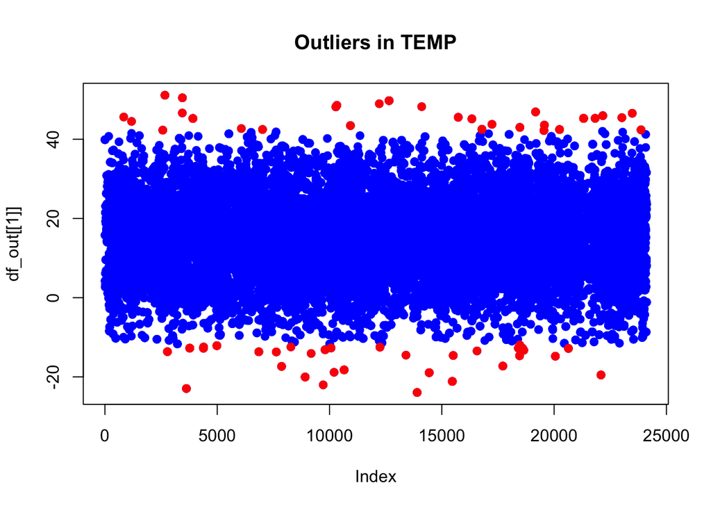

```r
outliers_list <- lapply(df_out, function(column) {
  IQR_value <- IQR(column, na.rm = TRUE)
  upper_bound <- quantile(column, 0.75, na.rm = TRUE) + 1.5 * IQR_value
  lower_bound <- quantile(column, 0.25, na.rm = TRUE) - 1.5 * IQR_value
  lower_outliers <- which(column < lower_bound)
  upper_outliers <- which(column > upper_bound)
  return(list(lower_outliers = lower_outliers, upper_outliers = upper_outliers))
})


plot(df_out[[1]], main=paste("Outliers in", names(df_out)[1]), col="blue", pch=19)
if(length(outliers_list[[1]]$lower_outliers) > 0) {
  points(outliers_list[[1]]$lower_outliers, df_out[outliers_list[[1]]$lower_outliers, 1], col="red", pch=19)
}
if(length(outliers_list[[1]]$upper_outliers) > 0) {
  points(outliers_list[[1]]$upper_outliers, df_out[outliers_list[[1]]$upper_outliers, 1], col="red", pch=19)
}
```

# Pokročilé skúmanie dát

## Waring

Spočítame počet varovaní a vypočítame percento

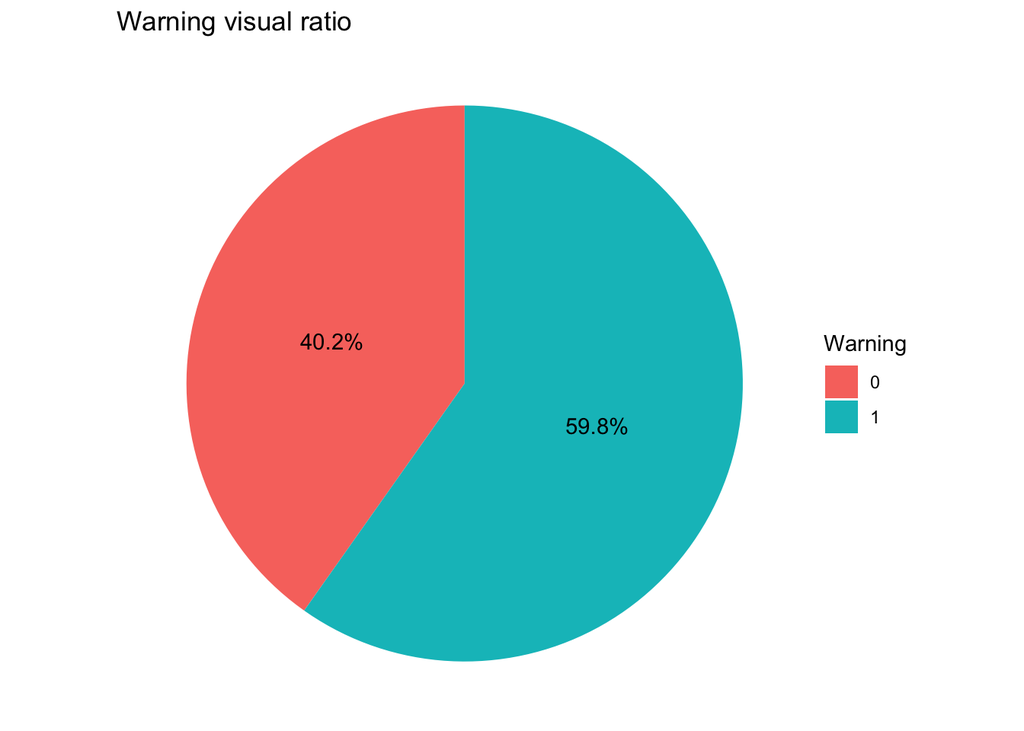

```r
war_count <- df %>%
  count(warning) %>%
  rename(Warning = warning, Count = n) %>%
  mutate(Percentage = Count / sum(Count) * 100)

# Vykreslenie počtu varovaní ako koláčový graf s percentami
ggplot(war_count, aes(x = "", y = Percentage, fill = factor(Warning))) +
  geom_bar(width = 1, stat = "identity") +
  coord_polar("y") +
  theme_void() +
  labs(title = "Warning visual ratio", fill = "Warning") +
  geom_text(aes(label = paste0(round(Percentage, 1), "%")), position = position_stack(vjust = 0.5)) +
  scale_fill_discrete(breaks = c("0", "1"))
```

```r
# Vytvorenie funkcie na vykreslenie histogramov pre každý stĺpec
plot_histogram <- function(column_name, data) {
  ggplot(data, aes(x = !!sym(column_name))) +
    geom_histogram(bins = 50, fill = "blue", color = "black") +
    labs(title = paste("Histogram of", column_name), x = column_name, y = "Frequency") +
    theme_minimal()
}
```

Vygenerovanie zoznamu grafov histogramov pre každý stĺpec v df

```r
histogram_plots <- lapply(colnames(df), function(col) plot_histogram(col, df))
```

## Výpočet skewness

```r
# Identifikácia riadkov s nečíselnými hodnotami v údajne číselnom stĺpci
df_nums_only <- df %>%
  select_if(is.numeric)

# skontrolujeme každý číselný stĺpec, či sa v ňom nenachádzajú hodnoty, ktoré sa nedajú dať na číslo
for (col in names(df_nums_only)) {
  if (is.factor(df_nums_only[[col]])) {
    df_nums_only[[col]] <- as.character(df_nums_only[[col]])
  }

  if (!all(sapply(df_nums_only[[col]], is.numeric))) {
    warning(paste("Non-numeric values found in column:", col))
    df_nums_only[[col]] <- as.numeric(as.character(df_nums_only[[col]]))
  }
}
sapply(df_nums_only, skewness)
```

```
##      warning         TEMP         PRES        PM2.5          NOx         PM10
## -0.399138331 -0.047277102  0.014857470 -0.207805263 -0.003169103  0.084101449
##      C2H3NO5          CH4           Pb          NH3          SO2           O3
## 10.370797709 -0.012169859 -0.017125107  0.155660828 -0.090366831 -0.136491414
##           CO         PAHs         H2CO         CFCs
## -0.214275542  0.003354208 -0.024672846 -0.041707352
```

## Korelačná matica

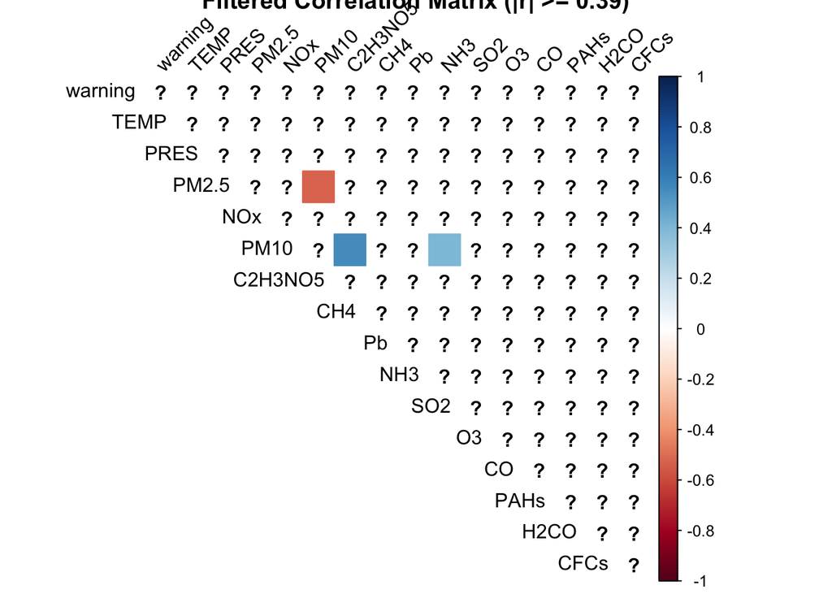

```r
df_nums_only_corr <- cor(df_nums_only, use = "complete.obs")  # 'use' parameter handluje NA hodnoty

# Vytvorenie masky pre hodnoty, ktoré spĺňajú kritériá
# vyfiltrovanie korelácií s abs hodnotou podla:
threshold_high <- 0.39
threshold_low <- -0.39
mask <- abs(df_nums_only_corr) >= threshold_high & df_nums_only_corr != 1

# nahradenie hodnot kt nesplnanu kriteria NaNkom
filtered_corr_matrix <- df_nums_only_corr
filtered_corr_matrix[!mask] <- NA

# vykreslime filtrovanú korelačnú maticu
corrplot(filtered_corr_matrix, method = "color", type = "upper", tl.col = "black", tl.srt = 45, title = "Filtered Correlation Matrix (|r| >= 0.39)")
```

Významnejšie korelácie sa javia byť medzi týmito atribútmi:  
- PM2.5 - PM10  
- PM10 - NH3  
- PM10 - C2H3NO5

# Hypotézy

## HYPO 1

Hladiny PM2.5, ktoré sú považované za najškodlivejšie znečistenie, sú lineárne závislé od hladín PM10, SO2 a CO. ## HYPO 2 Atribúty PM2.5, PM10, NH3, C2H3NO5 majú štatický významný vplyv na predikciu varovania v podobe premennej warning.

# Lineárna regressia

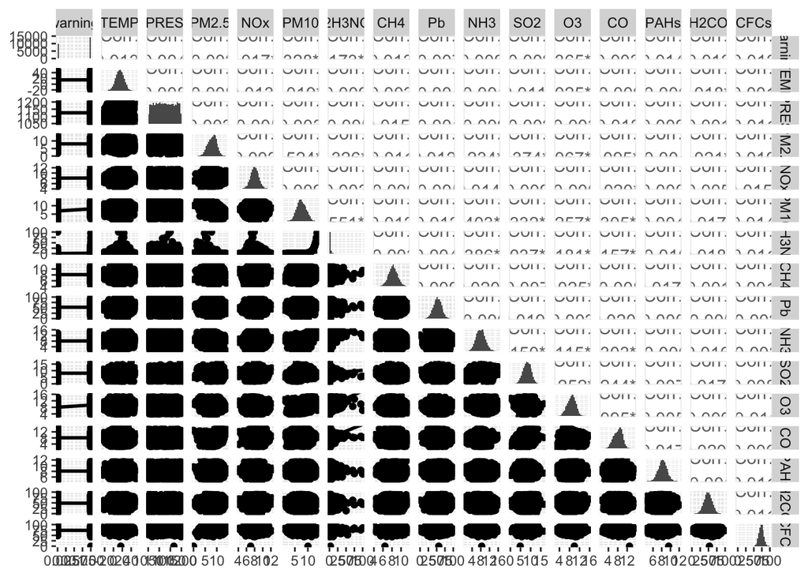

```r
numeric_df <- df[sapply(df, is.numeric)]
ggpairs(numeric_df,
        lower = list(continuous = "smooth"),
        diag = list(continuous = "barDiag"))
```

## Rozdelíme dáta na trénovacie a testovacie a vytvoríme Model

```r
set.seed(123)
sample <- sample(c(TRUE, FALSE), nrow(df), replace = TRUE, prob = c(0.5, 0.3))
train_data <- df[sample,]
test_data <- df[!sample,]

# PM2.5 – the most harmful pollution
# PM10 - Particulate Matter (µg/m3)
# SO2 - Sulfur Dioxide  (µg/m3)
# CO - Carbon Monoxide emissions  (µg/m3)
PM25Model <- lm(PM2.5 ~ PM10  + SO2 + CO, data = train_data)
summary(PM25Model)
```

```
##
## Call:
## lm(formula = PM2.5 ~ PM10 + SO2 + CO, data = train_data)
##
## Residuals:
##     Min      1Q  Median      3Q     Max
## -8.1487 -1.0612  0.0896  1.1008  6.5548
##
## Coefficients:
##              Estimate Std. Error t value Pr(>|t|)
## (Intercept) 12.834566   0.074879  171.41   <2e-16 ***
## PM10        -0.495697   0.007707  -64.32   <2e-16 ***
## SO2         -0.236042   0.006927  -34.08   <2e-16 ***
## CO           0.111353   0.007168   15.53   <2e-16 ***
## ---
## Signif. codes:  0 '***' 0.001 '**' 0.01 '*' 0.05 '.' 0.1 ' ' 1
##
## Residual standard error: 1.588 on 15103 degrees of freedom
## Multiple R-squared:  0.3233, Adjusted R-squared:  0.3231
## F-statistic:  2405 on 3 and 15103 DF,  p-value: < 2.2e-16
```

## Vy-plotujeme si model

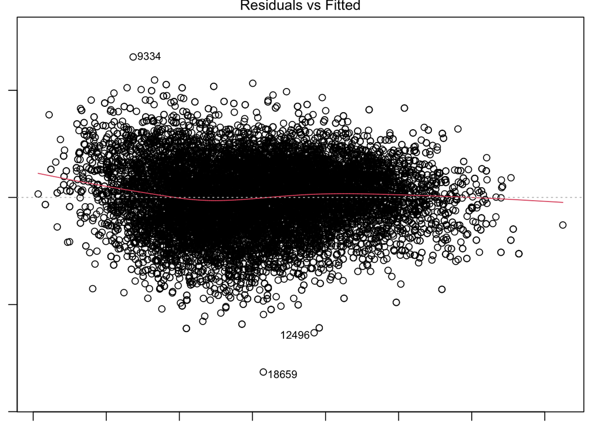

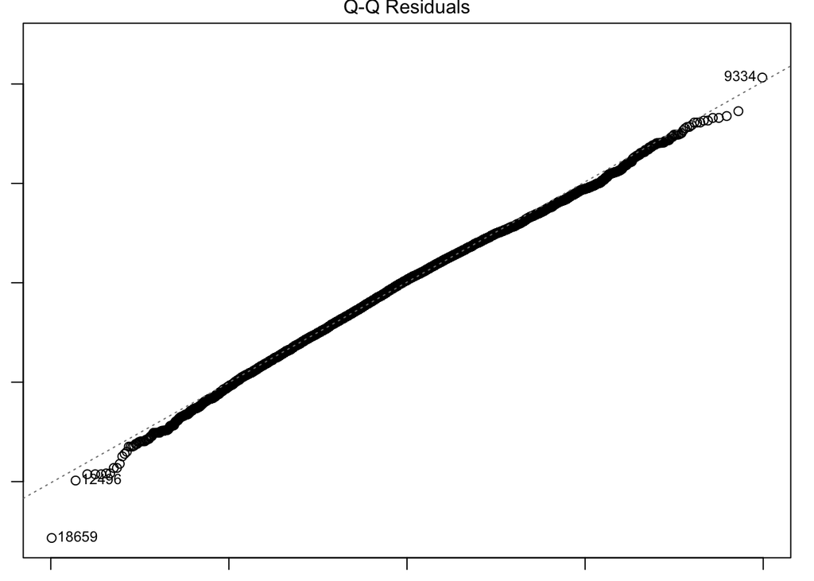

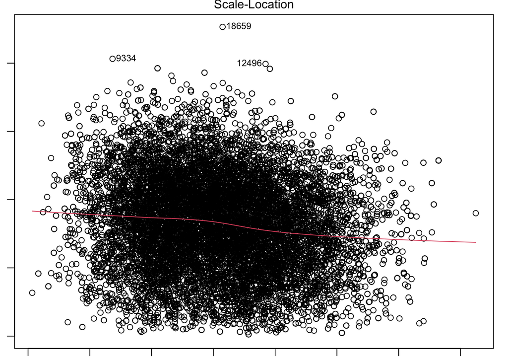

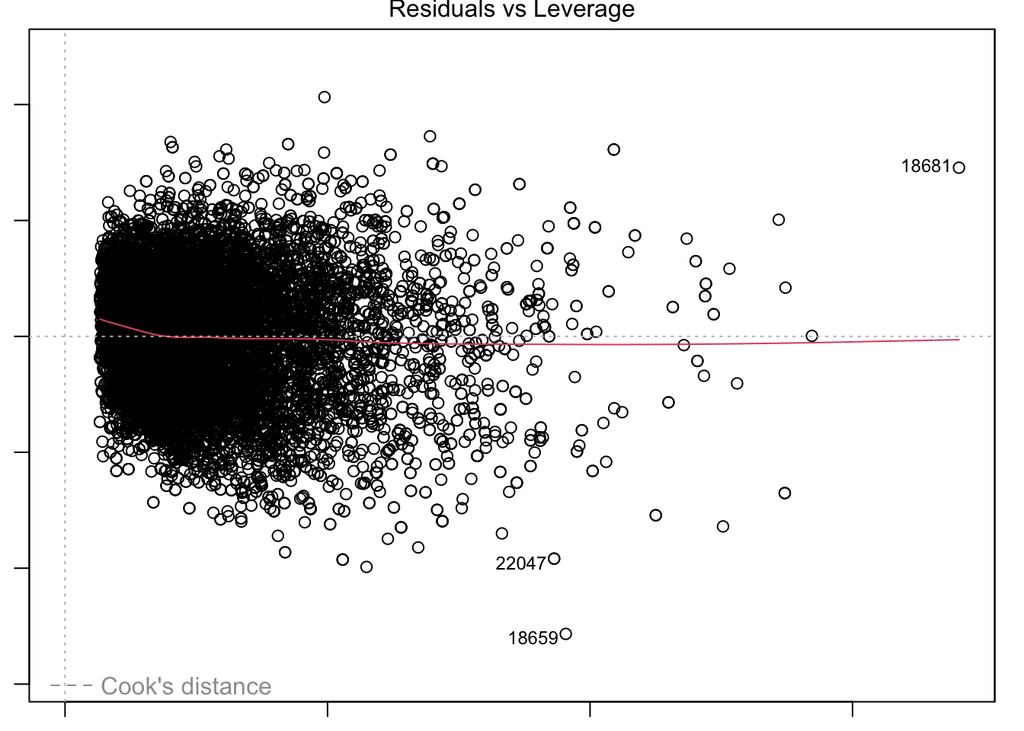

```r
par(mar = c(1, 1, 1, 1))
plot(PM25Model)
```

## Vyhodnotenie plotov

Residuals vs Fitted - Červená čiara by mala horizontálna najviac ako je možná - Ak je čiara nakrivená može to znamenať nelineárny vzťah - Detekuje odlahlé body

Normal QQ - Kontrolujeme či residuals majú normálovu distribúciu - Ak sú rezíduá normálne distribuované, body na grafe by mali vytvoriť približne priamu čiaru - Ak sú body na Q-Q grafe zakrivené alebo majú iné neštandardné vzory, môže to naznačovať, že rezíduá majú neobvyklé rozdelenie - V našom prípade to vyzerá že residualy majú normálovú distribúciu

Scale-Location (Spread location) - Čiara je takmer horizontálna takže mohli by sme povedať že residuals sú rovnomerne rozložené

Residuals vs Leverage: - zobrazuje ovplivnujúce časti - niečo podobné ako outliery - ak by sme videli v rohoch čiary tak je možné že to nieje v poriadku

# Predikovanie na základe testovacích dáta + manuálne overenie

```r
predicted_values <- predict(PM25Model, newdata = test_data)

# PM25 = 12.88 - 0.11 * PM10 - 0.23 * SO2 + 0.10 * CO
cat("Expected: 5.72081 , Predicted: ",predict(PM25Model,data.frame(PM10=5.85838,  SO2=11.00024, CO=7.00959)))
```

```
## Expected: 5.72081 , Predicted:  8.114608
```

```r
mean_absolute_error <- mean(abs(predicted_values - test_data$PM2.5))
mean_squared_error <- mean((predicted_values - test_data$PM2.5)^2)
root_mean_squared_error <- sqrt(mean_squared_error)

data.frame(Metric = c("Mean Absolute Error", "Mean Squared Error", "Root Mean Squared Error"), Value = c(mean_absolute_error,mean_squared_error,root_mean_squared_error))
```

```
##                    Metric    Value
## 1     Mean Absolute Error 1.255622
## 2      Mean Squared Error 2.448739
## 3 Root Mean Squared Error 1.564845
```

## Vyhodnotenie na základe metrík

MAE - meria absolutnu chybu medzi predikovanými hodnotami a skutočnímy

MSE - meria priemernu velkost chyb p redikciach modelu, a tak kvantifikuje rozdiel medzi skutočnými a predikovanými hodnotami

RMSE -> poskytuje prehlad o tom ako dobre model predikuje alebo ako blízko sú predikcie k skutočním hodnotám

## Vizualizácia predikovaných dát

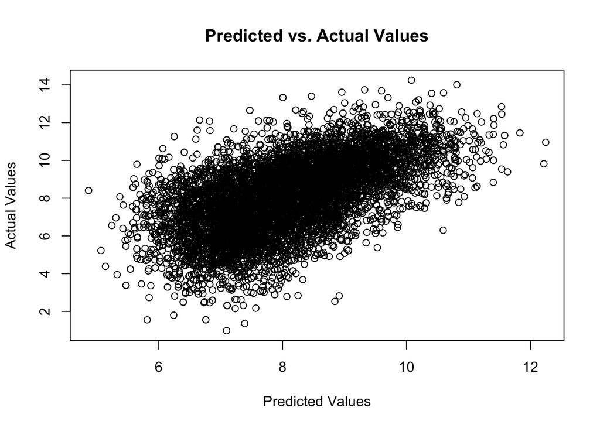

```r
plot(x=predicted_values, y=test_data$PM2.5,
     xlab='Predicted Values',
     ylab='Actual Values',
     main='Predicted vs. Actual Values')
```

```r
head(data.frame(actual=test_data$PM2.5, predicted=predicted_values))
```

```
##     actual predicted
## 2  5.72081  8.114608
## 4  5.72081  8.114608
## 5  6.15657  7.385383
## 8  6.15657  7.385383
## 11 5.01126  7.391529
## 13 5.82819  7.215109
```

# Klasifikácia

Warning je kategorický atribút, preto ho musíme pretypovať na faktor

```r
df$warning <- as.factor(df$warning)
```

## Rozdelenie train a test

```r
set.seed(123)
#cat('nrow', nrow(df))
#cat('ncol', ncol(df))
index <- sample(seq_len(nrow(df)), round(0.7 * nrow(df)))
trainData <- df[index,]
testData <- df[-index,]
```

## Natrenovanie modelu

```r
# binomial distribúcii, ktorá je vhodná pre binárnu logistickú regresiu.
logisticModel <- glm(warning ~ PM2.5 + PM10 + NH3 + C2H3NO5, data = trainData, family = binomial())
```

- Std. Error: Štandardné chyby odhadov koeficientov. Menšie hodnoty ukazujú väčšiu presnosť odhadov koeficientov.
- P-hodnoty pre testy z. Nízke p-hodnoty (v tomto prípade menšie ako 2e-16) naznačujú, že príslušné koeficienty sú štatisticky významné.
- V tomto prípade všetky prediktívne premenné majú významný vplyv na premennú

```r
summary(logisticModel)
```

```
##
## Call:
## glm(formula = warning ~ PM2.5 + PM10 + NH3 + C2H3NO5, family = binomial(),
##     data = trainData)
##
## Coefficients:
##              Estimate Std. Error z value Pr(>|z|)
## (Intercept) -5.130687   0.180718 -28.391   <2e-16 ***
## PM2.5        0.307108   0.011165  27.505   <2e-16 ***
## PM10         0.577838   0.016466  35.093   <2e-16 ***
## NH3         -0.177567   0.009522 -18.649   <2e-16 ***
## C2H3NO5      0.168006   0.019614   8.566   <2e-16 ***
## ---
## Signif. codes:  0 '***' 0.001 '**' 0.01 '*' 0.05 '.' 0.1 ' ' 1
##
## (Dispersion parameter for binomial family taken to be 1)
##
##     Null deviance: 22738  on 16884  degrees of freedom
## Residual deviance: 19630  on 16880  degrees of freedom
## AIC: 19640
##
## Number of Fisher Scoring iterations: 6
```

### Predikcia na teste

```r
# výpočet predpovedí logistickej regresie na základe predtým natrénovaného modelu
probabilities <- predict(logisticModel, newdata = testData, type = "response")

# Na základe vrátených pravdepodobností priraďujeme triedy
# Ak je pravdepodobnosť väčšia ako 0.5, priradí sa hodnota reprezentujúca TRUE warning
# Ak je menšia alebo rovná 0.5, priradí sa FALSE warning
predictions <- ifelse(probabilities > 0.5, levels(testData$warning)[2], levels(testData$warning)[1])

# konvertuje predpovedané hodnoty na faktorovú premennú s úrovňami definovanými v originálnej premennej
predictions <- factor(predictions, levels = levels(testData$warning))
```

### Evaluacia modelu

```r
confMatrix <- table(Predicted = predictions, Actual = testData$warning)
print(confMatrix)
```

```
##          Actual
## Predicted    0    1
##         0 1542  604
##         1 1391 3699
```

confusionMatrix je tabuľka, ktorá ukazuje počty správnych a nesprávnych predikcií modelu v porovnaní s aktuálnymi hodnotami. V tomto prípade sú predictions predpovedané hodnoty z modelu, a testData$warning sú skutočné hodnoty cieľovej premennej. Objekt confMat potom obsahuje túto metriku spolu s ďalšími štatistikami výkonu modelu.

```r
confMat <- confusionMatrix(predictions, testData$warning)
confMatMatrix <- as.matrix(confMat$table)
```

Melt mení confMatMatrix do dlhého formátu. Dlhý formát je užitočný pre vizualizáciu, pretože každý riadok reprezentuje jednu hodnotu s príslušnými identifikátormi. Výsledný objekt confMatMelted má tri stĺpce: - jeden pre skutočné hodnoty - jeden pre predpovedané hodnoty - a jeden pre počet pozorovaní pre každú kombináciu skutočných a predpovedaných hodnôt

```r
confMatMelted <- melt(confMatMatrix)
# Actual - predstavuje skutočné hodnoty
# Predicted - predikované hodnoty
# Value - počet prípadov pre každú kombináciu skutočnej a predpovedanej hodnoty
colnames(confMatMelted) <- c('Actual', 'Predicted', 'Value')
```

## Konštatovanie výsledkov

```r
# Vytvorenie ROC objektu
roc_obj <- roc(testData$warning, probabilities)
```

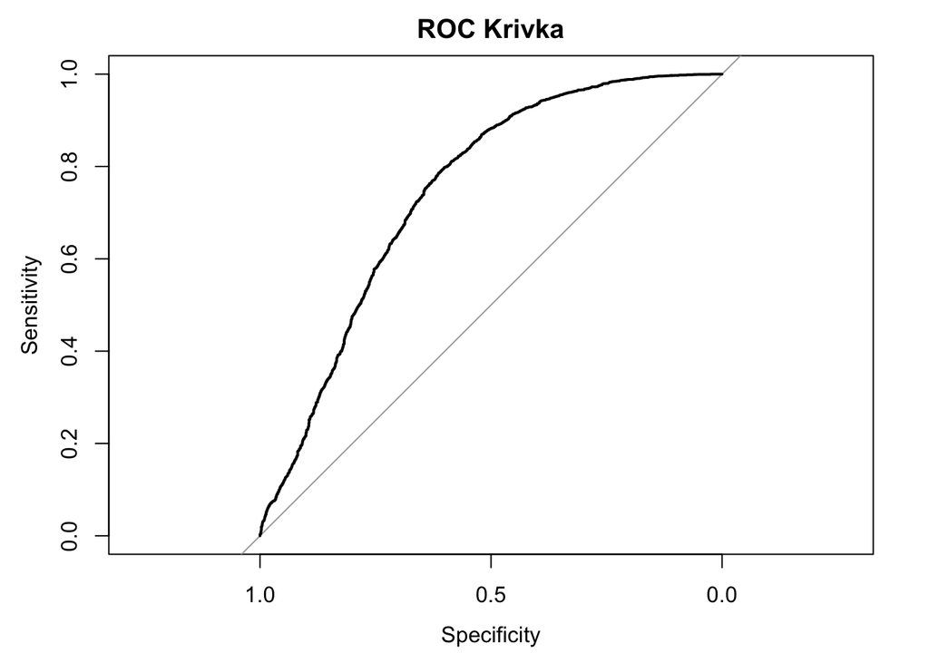

```r
# Výpis ROC krivky
plot(roc_obj, main="ROC Krivka")
```

```r
# Hľadanie optimálneho cut-off bodu
# Zvyčajne chceme maximalizovať Youdenov index (J), ktorý je definovaný ako sensitivity + specificity - 1
coords(roc_obj, "best", best.method="youden")
```

```
##   threshold specificity sensitivity
## 1 0.5518007   0.6137061   0.7859633
```

```r
# Vypočítajme krivku ROC a nájdime optimálny point
roc_obj <- roc(testData$warning, probabilities)
```

```r
optimal <- coords(roc_obj, "best", best.method="youden")
optimal_threshold <- optimal$threshold

# Kontrola platnosti optimálnych súradníc
if (!is.null(optimal$x) && !is.null(optimal$y)) {
  # Plot ROC curve
  plot(roc_obj, main="ROC Curve with Optimal Threshold")

  # bod pre optimal threshold
  points(optimal$x, optimal$y, pch=19, col="red")

  # pridaj text label pre optimal threshold
  text(optimal$x, optimal$y, labels=paste("Threshold:", round(optimal_threshold, 3)), pos=4)
    segments(optimal$x, optimal$y, optimal$x, 0, col="red", lty=2)
} else {
  cat("Optimal coordinates are not available.\n")
}
```

```
## Optimal coordinates are not available.
```

```r
p <- ggplot(confMatMelted, aes(x = Actual, y = Predicted, fill = Value)) +
  geom_tile(color = "white") +  # Tiles for each combination of actual and predicted
  geom_text(aes(label = Value), color = "black", size = 5) +  # prida text pre kazdu dlaždicu
  scale_fill_gradient(low = "white", high = "steelblue") +  # farba gradientu
  theme_minimal() +
  theme(axis.text.x = element_text(angle = 45, vjust = 1, size = 12, hjust = 1)) +  # prida x-axis text
  xlab('Predicted') +  # X-axis label
  ylab('Actual') +  # Y-axis label
  ggtitle('Confusion Matrix - Logistic Regression')  # title
```

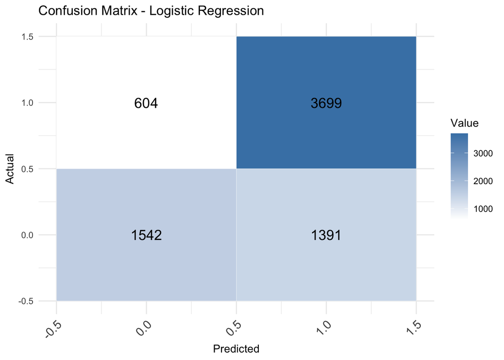

```r
print(p)
```